# IE 582 Statistical Learning for Data Mining - Homework 3

Can Hakan Dagidir

# Homework Description

We are interested in hourly electric consumption of Turkey. The consumption series are made publicly available by EPİAŞ @ https://seffaflik.epias.com.tr/transparency/. We will approach the data with different regession models and compare them at the end. Each approach will be explained in the corresponding part.

## Preperations

Before we start the tasks, let’s set up the environment and format the data in a way we can work easily.

```r
require(ggplot2, quietly=TRUE)
require(MLmetrics,quietly=TRUE)
require(glmnet,quietly=TRUE)

# x will be our dataframe
x <- read.csv("/Users/canhakan/Downloads/hw3data_utf.csv", header = TRUE, dec=",",check.names = F)

colnames(x) <- c('Date','Time','Consumption')
x$Consumption <- gsub('\\.','',x$Consumption)
x$Consumption <- gsub(',','\\.',x$Consumption)
x$Consumption <- as.numeric(x$Consumption)
```

## Part A

In this part we will approach naively and try to guess the hourly consumption directly by 2 or 7 days priors consumption.

First we create two columns for “lag” data and then format the Date and Time columns:

```r
lag48_end <- length(x$Consumption)-48
lag48 <- c(rep(0,48),x$Consumption[1:lag48_end])

lag168_end <- length(x$Consumption)-168
lag168 <- c(rep(0,168),x$Consumption[1:lag168_end])
x <- cbind(x,lag48,lag168)

# Date as date Time as an integer
x$Date <- as.Date(x$Date, "%d.%m.%Y")
x$Time <- as.numeric(sub(':.*','',x$Time))
```

Now we can see how precise our guess is

```r
lag48_mape  <- MAPE(x[x$Date >= '2020-11-01',]$lag48,  x[x$Date >= '2020-11-01',]$Consumption)
lag168_mape <- MAPE(x[x$Date >= '2020-11-01',]$lag168, x[x$Date >= '2020-11-01',]$Consumption)

cat(' lag48 mape value is:',lag48_mape,'\n',
    'lag168 mape value is:',lag168_mape)
```

```
##  lag48 mape value is: 0.08060315
##  lag168 mape value is: 0.03449188
```

We can see that the mean absolute error in lag 48 is more than double of the error in lag 168. In other words, in a naive approach, the data from the same day of last week is much more valuable than the data from two days ago.

## Part B

In this part we will use linear regression with “lag48” and “lag168” values to predict hourly consumptions. First some preperations:

```r
# Removing first 168 hours as they don't have lag values.
end_point <- length(x$Consumption)
x <- x[169:end_point,]

# Removing the days affected by the corrupted data because of the day light savings.
x <- x[x$Date != '2016-03-27',]
x <- x[x$Date != '2016-03-29',]
x <- x[x$Date != '2016-04-03',]
```

Now we are splitting the data as Train/Test, then doing a linear regression with the train data using lag48 and lag168 to be a predictor of consumption with also setting a seed for reproducibility.

```r
x_train <- x[x$Date<"2020-11-01",]
x_test <- x[x$Date>="2020-11-01",]

set.seed(2021)
lin_fit <- lm(Consumption~lag48+lag168, x_train)
summary(lin_fit)
```

```
##
## Call:
## lm(formula = Consumption ~ lag48 + lag168, data = x_train)
##
## Residuals:
##      Min       1Q   Median       3Q      Max
## -17125.7   -984.3     -1.2   1015.7  16097.4
##
## Coefficients:
##              Estimate Std. Error t value Pr(>|t|)
## (Intercept) 1.570e+03  8.351e+01   18.80   <2e-16 ***
## lag48       3.091e-01  3.096e-03   99.82   <2e-16 ***
## lag168      6.430e-01  3.094e-03  207.83   <2e-16 ***
## ---
## Signif. codes:  0 '***' 0.001 '**' 0.01 '*' 0.05 '.' 0.1 ' ' 1
##
## Residual standard error: 2388 on 42141 degrees of freedom
## Multiple R-squared:  0.7757, Adjusted R-squared:  0.7757
## F-statistic: 7.288e+04 on 2 and 42141 DF,  p-value: < 2.2e-16
```

Above, we can see the explanation of the linear fit. We see that all coefficients are significant.

Now we can use that model to predict our test data and then compare it with the real consumption variables of the test data.

```r
x_pred <- predict(lin_fit,x_test)
lin_mape <- MAPE(x_pred, x_test$Consumption)
cat('MAPE value for our linear model is ', lin_mape)
```

```
## MAPE value for our linear model is  0.04231015
```

We can see that that MAPE is worse than naive lag168. So it is not an effective approach.

## Part C

In this part, we will only use the consumption data of the same hour for training. Below you can see the summary of MAPE values.

```r
res_mape <- data.frame('Hours'=integer(),
                 'MAPE'=double())
for (t in c(0:23)){
    x_temp <- x[x$Time == t,]
    x_temp_train <- x_temp[x_temp$Date < '2020-11-01',]
    x_temp_test <- x_temp[x_temp$Date >= '2020-11-01',]
    fit_temp <- lm(Consumption~lag48+lag168,x_temp_train)
    x_temp_pred <- predict(fit_temp,x_temp_test)
    res_mape <- rbind(res_mape,c(t,MAPE(x_temp_pred,x_temp_test$Consumption)))
}
colnames(res_mape) <- c('Hour', 'MAPE')
summary(res_mape$MAPE)
```

```
##    Min. 1st Qu.  Median    Mean 3rd Qu.    Max.
## 0.03151 0.03200 0.03590 0.04361 0.05643 0.06687
```

Above we can see some of the values are a little better than naive lag_168 approach. Let’s take a closer look:

```r
res_mape <- cbind(res_mape,lag168_mape-res_mape[,2])
colnames(res_mape) <- c('Hour', 'MAPE', 'Difference')
res_mape[res_mape[,3] > 0,]
```

|  | Hour | MAPE | Difference |
| --- | --- | --- | --- |
| 1 | 0 | 0.0326354 | 0.0018565 |
| 2 | 1 | 0.0328359 | 0.0016560 |
| 3 | 2 | 0.0341899 | 0.0003020 |
| 4 | 3 | 0.0320295 | 0.0024624 |
| 5 | 4 | 0.0318297 | 0.0026621 |
| 6 | 5 | 0.0318914 | 0.0026005 |
| 7 | 6 | 0.0315087 | 0.0029832 |
| 20 | 19 | 0.0343613 | 0.0001306 |
| 21 | 20 | 0.0316530 | 0.0028388 |
| 22 | 21 | 0.0316704 | 0.0028215 |
| 23 | 22 | 0.0316730 | 0.0028189 |
| 24 | 23 | 0.0338720 | 0.0006199 |

An interesting thing to note: Between 7pm and 6am (the darker half of the day), our regression has less error than the naive approach.

## Part D

Now we will transform our data to ‘wide’ format. And use every hours consumption value from 2 or 7 days ago to predict consumption. We will use Lasso regression and do 10-fold cross-validation for choosing the best lambda.

For representation, I will show the process with detail for Hour 0:

```r
# First we get the unique dates
unique_dates <- unique(x$Date)
m <- data.frame()
for (date_index in 1:length(unique_dates)){
    date <- as.Date(unique_dates[date_index],origin='2020-11-24')
    m <- rbind(m, cbind.data.frame(date, t(x[x$Date == date,]$lag168), t(x[x$Date == date,]$lag48), x[x$Date == date,][x$Time == 0,]$Consumption[1]))
}
for (j in c(2:25)){
    colnames(m)[j] <- paste('Lag_day7_hour',j-2,sep='_')
}
for (j in c(26:49)){
    colnames(m)[j] <- paste('Lag_day2_hour',j-26,sep='_')
}
colnames(m)[50] <- 'Consumption_0'
colnames(m)[1] <- 'Date'

head(m)
```

| Date | Lag_day7_hour_0 | Lag_day7_hour_1 | Lag_day7_hour_2 | Lag_day7_hour_3 | Lag_day7_hour_4 | Lag_day7_hour_5 | Lag_day7_hour_6 | Lag_day7_hour_7 | Lag_day7_hour_8 | Lag_day7_hour_9 | Lag_day7_hour_10 | Lag_day7_hour_11 | Lag_day7_hour_12 | Lag_day7_hour_13 | Lag_day7_hour_14 | Lag_day7_hour_15 | Lag_day7_hour_16 | Lag_day7_hour_17 | Lag_day7_hour_18 | Lag_day7_hour_19 | Lag_day7_hour_20 | Lag_day7_hour_21 | Lag_day7_hour_22 | Lag_day7_hour_23 | Lag_day2_hour_0 | Lag_day2_hour_1 | Lag_day2_hour_2 | Lag_day2_hour_3 | Lag_day2_hour_4 | … |
| --- | --- | --- | --- | --- | --- | --- | --- | --- | --- | --- | --- | --- | --- | --- | --- | --- | --- | --- | --- | --- | --- | --- | --- | --- | --- | --- | --- | --- | --- | --- |
| 2016-01-08 | 26277.24 | 24991.82 | 23532.61 | 22464.78 | 22002.91 | 21957.08 | 22203.54 | 21844.16 | 23094.73 | 25202.27 | 27224.96 | 28908.04 | 28789.25 | 29367.70 | 29548.32 | 29390.89 | 30734.97 | 32048.02 | 31438.11 | 30728.47 | 30166.14 | 29461.28 | 29242.83 | 28069.09 | 29189.27 | 27614.02 | 26578.97 | 25719.19 | 25864.63 | … |
| 2016-01-09 | 26224.60 | 24708.58 | 23771.58 | 22921.29 | 22870.89 | 23325.63 | 23604.98 | 24022.70 | 26930.48 | 30043.60 | 32102.38 | 33431.89 | 32910.61 | 32887.61 | 32796.18 | 32594.55 | 33358.47 | 34387.95 | 33591.26 | 32648.83 | 31897.73 | 31049.20 | 30906.43 | 29621.09 | 28763.95 | 27284.84 | 26321.95 | 25748.49 | 25636.58 | … |
| 2016-01-10 | 27613.96 | 25779.28 | 24566.31 | 23878.42 | 23511.38 | 23672.32 | 23827.08 | 23405.11 | 24638.72 | 26802.38 | 28779.88 | 30204.30 | 30588.30 | 30902.63 | 31056.47 | 30979.53 | 32297.46 | 33462.96 | 33151.03 | 32450.21 | 32093.93 | 31315.16 | 31014.19 | 29462.06 | 28602.02 | 27112.37 | 25975.34 | 25315.55 | 25128.15 | … |
| 2016-01-11 | 27103.09 | 25439.84 | 24395.07 | 23961.03 | 23860.63 | 24418.47 | 25708.59 | 27455.39 | 32982.07 | 37175.84 | 38606.67 | 39659.57 | 38416.32 | 39279.26 | 39661.98 | 39211.00 | 39760.12 | 39633.29 | 37621.41 | 35954.18 | 35114.12 | 34066.40 | 33686.83 | 31733.54 | 29906.93 | 28061.98 | 26808.78 | 25798.80 | 25820.46 | … |
| 2016-01-12 | 29244.38 | 27637.23 | 26335.78 | 25870.23 | 25975.07 | 26318.48 | 27109.29 | 28570.22 | 33106.00 | 36657.12 | 37776.49 | 38664.22 | 37522.11 | 37820.69 | 38086.11 | 37834.89 | 38599.34 | 38669.63 | 36954.78 | 35306.11 | 34301.59 | 33400.82 | 33359.37 | 31629.97 | 28890.37 | 27133.75 | 25656.13 | 24937.87 | 24538.16 | … |
| 2016-01-13 | 29189.27 | 27614.02 | 26578.97 | 25719.19 | 25864.63 | 25918.59 | 27091.94 | 28533.05 | 33203.34 | 36257.22 | 37212.91 | 37844.74 | 36194.13 | 36542.73 | 36847.22 | 36433.88 | 37581.09 | 37304.52 | 35832.00 | 34499.94 | 33670.00 | 32931.12 | 32913.06 | 31450.65 | 27130.75 | 25403.40 | 24452.96 | 23959.85 | 23839.28 | … |

We can see that the first column represents the date which is now unique in our dataframe. Columns from 2 to 25 represent lag168 values of the same day and columns from 26 to 49 represent lag48 values. The 50th column has the actual consumption value at 12 AM of the given date.

Now, we split our data and do 10-fold cross validation to find a good lambda.

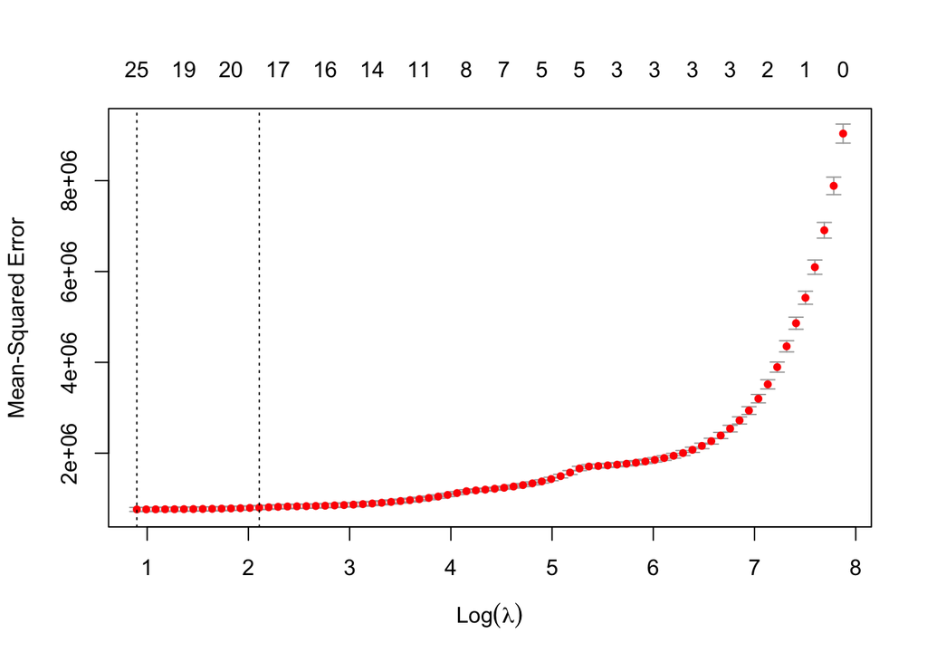

```r
wide_data <- m
wide_train <-wide_data[wide_data$Date < '2020-11-01', ]
wide_test <- wide_data[wide_data$Date >= '2020-11-01', ]

set.seed(2021)
lasso_d = cv.glmnet(as.matrix(wide_train[,2:49]),as.matrix(wide_train[,50]),nfolds=10,family='gaussian')
plot(lasso_d)
```

```r
lasso_d
```

```
##
## Call:  cv.glmnet(x = as.matrix(wide_train[, 2:49]), y = as.matrix(wide_train[,      50]), nfolds = 10, family = "gaussian")
##
## Measure: Mean-Squared Error
##
##     Lambda Measure    SE Nonzero
## min  2.454  762136 44290      25
## 1se  8.226  802836 44948      18
```

While 2.4 gives the minimum value for lambda, 8.2 is also within 1 standard error. We will use both lambdas and compare them:

```r
model_d_min <- glmnet(as.matrix(wide_train[,2:49]),as.matrix(wide_train[,50]), alpha = 1, lambda = lasso_d$lambda.min)
model_d_1se <- glmnet(as.matrix(wide_train[,2:49]),as.matrix(wide_train[,50]), alpha = 1, lambda = lasso_d$lambda.1se)

predicted_wide_min <- predict(model_d_min,as.matrix(wide_test[,2:49]))
predicted_wide_1se <- predict(model_d_1se,as.matrix(wide_test[,2:49]))

cat(' MAPE value for lambda_min is ', MAPE(predicted_wide_min,wide_test[,50]), '\n',
      'MAPE value for lambda_1se is ', MAPE(predicted_wide_1se,wide_test[,50]))
```

```
##  MAPE value for lambda_min is  0.01403278
##  MAPE value for lambda_1se is  0.01458865
```

We can see that the results are pretty close to each other and more importantly the error is very low compared to other approaches. Now we will do the same process for other hours and show the errors in a table.

```r
mape_d <- data.frame('Hours'=integer(),
                     'MAPE_min'=double(),
                     'MAPE_1se'=double())
for (t in c(0:23)){
    m <- data.frame()
    for (date_index in 1:length(unique_dates)){
        date <- as.Date(unique_dates[date_index],origin='2020-11-24')
        m <- rbind(m, cbind.data.frame(date, t(x[x$Date == date,]$lag168), t(x[x$Date == date,]$lag48), x[x$Date == date,][x$Time == t,]$Consumption[1]))
    }
    for (j in c(2:25)){
        colnames(m)[j] <- paste('Lag_day7_hour',j-2,sep='_')
    }
    for (j in c(26:49)){
        colnames(m)[j] <- paste('Lag_day2_hour',j-26,sep='_')
    }
    colnames(m)[50] <- paste('Consumption',t,sep='_')
    colnames(m)[1] <- 'Date'

    wide_data <- m
    wide_train <-wide_data[wide_data$Date < '2020-11-01', ]
    wide_test <- wide_data[wide_data$Date >= '2020-11-01', ]

    set.seed(2021)
    lasso_d = cv.glmnet(as.matrix(wide_train[,2:49]),as.matrix(wide_train[,50]),nfolds=10,family='gaussian')
#     plot(lasso_d)
#     lasso_d

    model_d_min <- glmnet(as.matrix(wide_train[,2:49]),as.matrix(wide_train[,50]), alpha = 1, lambda = lasso_d$lambda.min)
    model_d_1se <- glmnet(as.matrix(wide_train[,2:49]),as.matrix(wide_train[,50]), alpha = 1, lambda = lasso_d$lambda.1se)

    predicted_wide_min <- predict(model_d_min,as.matrix(wide_test[,2:49]))
    predicted_wide_1se <- predict(model_d_1se,as.matrix(wide_test[,2:49]))

    mape_d <- rbind(mape_d, c(t,  MAPE(predicted_wide_min,wide_test[,50]),  MAPE(predicted_wide_1se,wide_test[,50])))
    cat('MAPE value for lambda_min at hour', t, ' is ', MAPE(predicted_wide_min,wide_test[,50]), '\t')
    cat('MAPE value for lambda_1se at hour', t, ' is ', MAPE(predicted_wide_1se,wide_test[,50]), '\n')
}
```

```
## MAPE value for lambda_min at hour 0  is  0.01403278  MAPE value for lambda_1se at hour 0  is  0.01458865
## MAPE value for lambda_min at hour 1  is  0.01560088  MAPE value for lambda_1se at hour 1  is  0.01512567
## MAPE value for lambda_min at hour 2  is  0.01487986  MAPE value for lambda_1se at hour 2  is  0.01533828
## MAPE value for lambda_min at hour 3  is  0.01397722  MAPE value for lambda_1se at hour 3  is  0.01368293
## MAPE value for lambda_min at hour 4  is  0.01399875  MAPE value for lambda_1se at hour 4  is  0.01366099
## MAPE value for lambda_min at hour 5  is  0.01409941  MAPE value for lambda_1se at hour 5  is  0.01378373
## MAPE value for lambda_min at hour 6  is  0.01713375  MAPE value for lambda_1se at hour 6  is  0.01633279
## MAPE value for lambda_min at hour 7  is  0.01798953  MAPE value for lambda_1se at hour 7  is  0.01785413
## MAPE value for lambda_min at hour 8  is  0.0260944   MAPE value for lambda_1se at hour 8  is  0.02533617
## MAPE value for lambda_min at hour 9  is  0.03641173  MAPE value for lambda_1se at hour 9  is  0.03645694
## MAPE value for lambda_min at hour 10  is  0.04108576     MAPE value for lambda_1se at hour 10  is  0.04287378
## MAPE value for lambda_min at hour 11  is  0.04394842     MAPE value for lambda_1se at hour 11  is  0.04499002
## MAPE value for lambda_min at hour 12  is  0.0467689  MAPE value for lambda_1se at hour 12  is  0.04745468
## MAPE value for lambda_min at hour 13  is  0.04550631     MAPE value for lambda_1se at hour 13  is  0.04665181
## MAPE value for lambda_min at hour 14  is  0.04294328     MAPE value for lambda_1se at hour 14  is  0.04386311
## MAPE value for lambda_min at hour 15  is  0.03840031     MAPE value for lambda_1se at hour 15  is  0.03910493
## MAPE value for lambda_min at hour 16  is  0.02972821     MAPE value for lambda_1se at hour 16  is  0.02977561
## MAPE value for lambda_min at hour 17  is  0.02106948     MAPE value for lambda_1se at hour 17  is  0.02061552
## MAPE value for lambda_min at hour 18  is  0.0167094  MAPE value for lambda_1se at hour 18  is  0.01569381
## MAPE value for lambda_min at hour 19  is  0.01568305     MAPE value for lambda_1se at hour 19  is  0.01452021
## MAPE value for lambda_min at hour 20  is  0.01655651     MAPE value for lambda_1se at hour 20  is  0.01553691
## MAPE value for lambda_min at hour 21  is  0.01691439     MAPE value for lambda_1se at hour 21  is  0.01625258
## MAPE value for lambda_min at hour 22  is  0.01603182     MAPE value for lambda_1se at hour 22  is  0.01471925
## MAPE value for lambda_min at hour 23  is  0.01810544     MAPE value for lambda_1se at hour 23  is  0.01739957
```

## Part F

We will compare MAPE values:

```r
mapes <- cbind(lag48_mape,lag168_mape, lin_mape, res_mape[,2], mape_d[,2], mape_d[,3])
colnames(mapes) <- c('Naive 48', 'Naive 168', 'Daily Linear', 'Hourly Linear', 'Lasso Min', 'Lasso 1se')
mapes
```

```
##         Naive 48  Naive 168 Daily Linear Hourly Linear  Lasso Min  Lasso 1se
##  [1,] 0.08060315 0.03449188   0.04231015    0.03263542 0.01403278 0.01458865
##  [2,] 0.08060315 0.03449188   0.04231015    0.03283588 0.01560088 0.01512567
##  [3,] 0.08060315 0.03449188   0.04231015    0.03418989 0.01487986 0.01533828
##  [4,] 0.08060315 0.03449188   0.04231015    0.03202953 0.01397722 0.01368293
##  [5,] 0.08060315 0.03449188   0.04231015    0.03182975 0.01399875 0.01366099
##  [6,] 0.08060315 0.03449188   0.04231015    0.03189139 0.01409941 0.01378373
##  [7,] 0.08060315 0.03449188   0.04231015    0.03150869 0.01713375 0.01633279
##  [8,] 0.08060315 0.03449188   0.04231015    0.03780175 0.01798953 0.01785413
##  [9,] 0.08060315 0.03449188   0.04231015    0.04680474 0.02609440 0.02533617
## [10,] 0.08060315 0.03449188   0.04231015    0.05494326 0.03641173 0.03645694
## [11,] 0.08060315 0.03449188   0.04231015    0.06094937 0.04108576 0.04287378
## [12,] 0.08060315 0.03449188   0.04231015    0.06279595 0.04394842 0.04499002
## [13,] 0.08060315 0.03449188   0.04231015    0.06547895 0.04676890 0.04745468
## [14,] 0.08060315 0.03449188   0.04231015    0.06686870 0.04550631 0.04665181
## [15,] 0.08060315 0.03449188   0.04231015    0.06485375 0.04294328 0.04386311
## [16,] 0.08060315 0.03449188   0.04231015    0.06087214 0.03840031 0.03910493
## [17,] 0.08060315 0.03449188   0.04231015    0.05151109 0.02972821 0.02977561
## [18,] 0.08060315 0.03449188   0.04231015    0.04613865 0.02106948 0.02061552
## [19,] 0.08060315 0.03449188   0.04231015    0.03743047 0.01670940 0.01569381
## [20,] 0.08060315 0.03449188   0.04231015    0.03436128 0.01568305 0.01452021
## [21,] 0.08060315 0.03449188   0.04231015    0.03165305 0.01655651 0.01553691
## [22,] 0.08060315 0.03449188   0.04231015    0.03167038 0.01691439 0.01625258
## [23,] 0.08060315 0.03449188   0.04231015    0.03167298 0.01603182 0.01471925
## [24,] 0.08060315 0.03449188   0.04231015    0.03387197 0.01810544 0.01739957
```

and here is a boxplot:

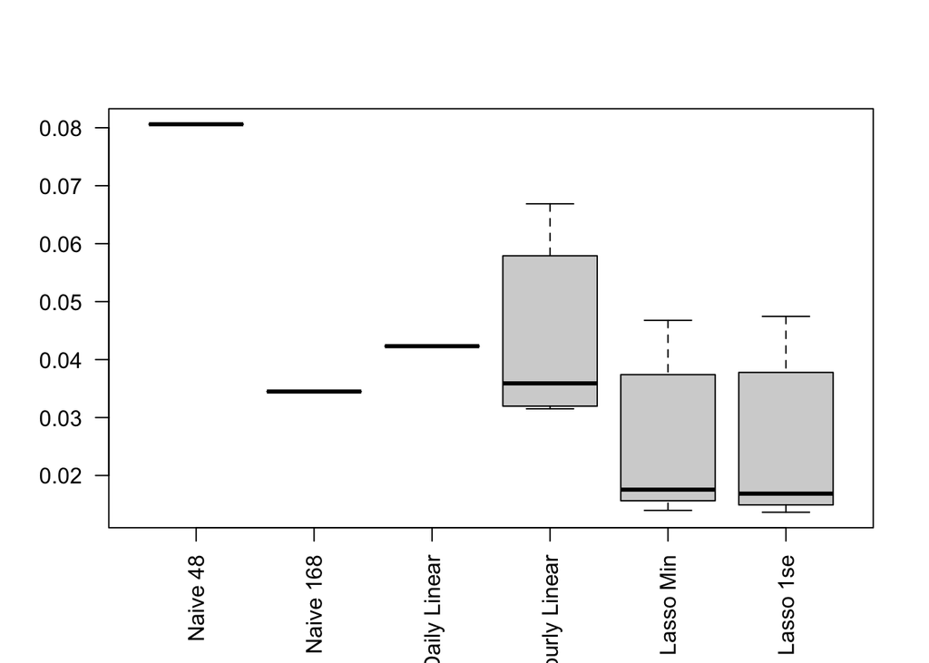

```r
boxplot(mapes, las=2)
```

We can clearly see that Lasso regression approaches are much better than others and there is not much of a difference between the choices of lambda (min vs 1se).